# Human activity recognition

Michal Svoboda

April 3, 2017

# Task

The data we have comes from a study where participants equiped with sensors were asked to perform an exercise sometimes correctly and other some times by doing distinct errors. The task is to use the data collected from the sensors and identify the modes of doing the excercise.

# Data preparation

Some data preparation is needed since there is lot of NA values in the data set, some numeric values are encoded as strings and some of the columns (participant names, times etc.) are not useful predictors.  
As it turned out, the columns that contained NAs always contained only small amount of valid data, so it was possible to remove them. For sake of saving computation power for the model creation I decided to partition the data into training set containing only 10 % of the original training set and a validation set containing the rest - 90 %.

```r
library(caret)
library(ggplot2)
library(dplyr)

#download the data and load it to R
# download.file("https://d396qusza40orc.cloudfront.net/predmachlearn/pml-training.csv",
#               method = "auto",
#               destfile = "training.csv")
#
# download.file("https://d396qusza40orc.cloudfront.net/predmachlearn/pml-testing.csv",
#               method = "auto",
#               destfile = "testing.csv")
training<-read.csv("training.csv",stringsAsFactors = F)
testing<-read.csv("testing.csv",stringsAsFactors = F)

#convert outcome to factor
training$classe<-as.factor(training$classe)

#remove variables that are not useful as predictors
training<-training %>% select(-X,-user_name,-raw_timestamp_part_1,-raw_timestamp_part_2,
                              -cvtd_timestamp,-new_window,-num_window)

#convert characters to numerics
training[,sapply(training,class)=="character"]<-sapply(training[,sapply(training,class)=="character"],as.numeric)
```

[output not shown]

[output cut: 10 more lines]

[output not shown]

```r
#get number of NAs in the columns and leave only the columns without NAs
naSums<-sapply(training,function(x){sum(is.na(x))})
naSumsTesting<-sapply(testing,function(x){sum(is.na(x))})
training<-training[,naSums==0]
testing<-testing[,naSumsTesting==0]

#partition the data into training set for model creation and validation set for cross validation
trainP1<-createDataPartition(training$classe,p=.1,list=FALSE)
tr1<-training[trainP1,] #training
tr2<-training[-trainP1,] #validation
```

# Model selection

Several strategies have been used to find the best model, that is the one having the highest accuracy on the validation set marked tr2 (that means the highest portion of correctly classified samples):

```r
set.seed(1000)
pp<-preProcess(tr1,method="pca",pcaComp = 3) #calculate PCA pre-processing method (plus centering and scaling)
tr1PP<-predict(pp,tr1) #apply pre-processing algorithm to training set
m1<-train(y=tr1PP$classe,x=tr1PP %>% select(-classe),method="rf") #create model from pre processed data using random forests
m1$results
```

```
##   mtry  Accuracy     Kappa AccuracySD    KappaSD
## 1    2 0.5062287 0.3749202 0.01669258 0.01972140
## 2    3 0.5020297 0.3694759 0.01553047 0.01850753
```

```r
rm(m1)
```

```r
set.seed(1000)
pp<-preProcess(tr1,method="pca")
tr1PP<-predict(pp,tr1)
m2<-train(y=tr1PP$classe,x=tr1PP %>% select(-classe),method="rf")
m2$results
```

```
##   mtry  Accuracy     Kappa AccuracySD    KappaSD
## 1    2 0.8190260 0.7711623 0.01439066 0.01798794
## 2   13 0.8007667 0.7480797 0.01671220 0.02098529
## 3   24 0.7888212 0.7329526 0.01965949 0.02468782
```

```r
tr2PP<-predict(pp,tr2) #apply pre processing on validation set
confusionMatrix(data=predict(m2,tr2PP %>% select(-classe)),reference=tr2PP$classe) #predict with model m2 on the validation set, show results
```

```
## Confusion Matrix and Statistics
##
##           Reference
## Prediction    A    B    C    D    E
##          A 4667  262   77   25   30
##          B  148 2731  160  119  203
##          C   48  284 2746  331  194
##          D  130   76   77 2357   68
##          E   29   64   19   62 2751
##
## Overall Statistics
##
##                Accuracy : 0.8637
##                  95% CI : (0.8586, 0.8688)
##     No Information Rate : 0.2844
##     P-Value [Acc > NIR] : < 2.2e-16
##
##                   Kappa : 0.8276
##  Mcnemar's Test P-Value : < 2.2e-16
##
## Statistics by Class:
##
##                      Class: A Class: B Class: C Class: D Class: E
## Sensitivity            0.9293   0.7992   0.8918   0.8144   0.8475
## Specificity            0.9688   0.9558   0.9412   0.9762   0.9879
## Pos Pred Value         0.9221   0.8126   0.7621   0.8704   0.9405
## Neg Pred Value         0.9718   0.9520   0.9763   0.9641   0.9664
## Prevalence             0.2844   0.1935   0.1744   0.1639   0.1838
## Detection Rate         0.2643   0.1547   0.1555   0.1335   0.1558
## Detection Prevalence   0.2866   0.1903   0.2040   0.1534   0.1656
## Balanced Accuracy      0.9491   0.8775   0.9165   0.8953   0.9177
```

```r
rm(m2)
```

- m3: This time no pre-processing was used and the predictors were selected based on exploratory scatter plots comparing pairs of variables. The variables were selected based on how separated the categories looked like. The resulting model has an accuracy of 89 % on the validation set. The confusion matrix has shown that differentiating class B is most challenging.

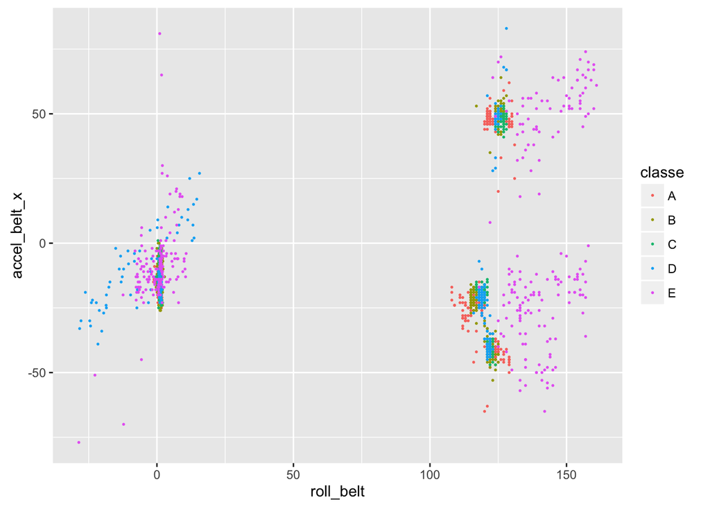

```r
set.seed(1000)

# manipulate is commented out because it cannot be included in html
# library(manipulate)
# manipulate(
#   ggplot(data=tr1,
#          aes_string(names(tr1)[var1],names(tr1)[var2],color=("classe")))+
#     geom_point(size=.3),
#   var1=slider(1,53,initial=8,step=1),
#   var2=slider(1,53,initial=1,step=1))

ggplot(data=tr1, aes_string(names(tr1)[1],names(tr1)[8],color=("classe")))+
    geom_point(size=.3)
```

```r
m3<-train(y=tr1$classe,x=tr1 %>% select(roll_belt,accel_belt_x,magnet_dumbbell_y,yaw_belt,pitch_forearm,accel_dumbbell_x,magnet_forearm_z),method="rf")
confusionMatrix(data=predict(m3,tr2 %>% select(-classe)),reference=tr2$classe)
```

```
## Confusion Matrix and Statistics
##
##           Reference
## Prediction    A    B    C    D    E
##          A 4628  245   37   50   19
##          B  117 2871  174   51  170
##          C  132  182 2710  165   72
##          D  129   98  137 2618   19
##          E   16   21   21   10 2966
##
## Overall Statistics
##
##                Accuracy : 0.8944
##                  95% CI : (0.8898, 0.8989)
##     No Information Rate : 0.2844
##     P-Value [Acc > NIR] : < 2.2e-16
##
##                   Kappa : 0.8665
##  Mcnemar's Test P-Value : < 2.2e-16
##
## Statistics by Class:
##
##                      Class: A Class: B Class: C Class: D Class: E
## Sensitivity            0.9215   0.8402   0.8802   0.9046   0.9137
## Specificity            0.9722   0.9640   0.9622   0.9741   0.9953
## Pos Pred Value         0.9295   0.8487   0.8310   0.8724   0.9776
## Neg Pred Value         0.9689   0.9618   0.9744   0.9812   0.9809
## Prevalence             0.2844   0.1935   0.1744   0.1639   0.1838
## Detection Rate         0.2621   0.1626   0.1535   0.1483   0.1680
## Detection Prevalence   0.2820   0.1916   0.1847   0.1700   0.1718
## Balanced Accuracy      0.9469   0.9021   0.9212   0.9393   0.9545
```

```r
#89
```

# Applying final model to testing dataset

The predicted values are shown below. If the neccessary score in the Coursera quiz were 80 %, that means min 16 correct out of 20, then the probability that we will fail in this test can be estimated from binomial distribution function and turns out to be approximately 6 % (of course some assumptions apply- i.e. that test set would be identically distributed as validation set).

```r
predict(m3,testing)
```

```
##  [1] B A B A A E D B A A B C B A E E A B B B
## Levels: A B C D E
```

```r
pbinom(15,20,.89) #probability of classifying correctly less than 16 values out of 20
```

```
## [1] 0.06102497
```

# Conclusion

It has been shown, that classification of the modes of excercise is possible with a reasonable accuracy given the predictors we have using the proposed model based on random forests algorithm. The model proved to be stable using the validation set of the size of 90 % of the data. The probability of failing to score at least 16 points out of 20 in the Coursera validation quiz was estimated to be about 6 %.